# **Problem Statement**

#### **Comment:**

✅ **Business Insight:**

- Model_5 delivers **one of the best recall-precision trade-offs** so far—**high sensitivity** to detect turbine failures while **minimizing costly false positives**. Its validation recall of **0.8784** and F1 score of **0.921** make it **extremely well-suited for ReneWind’s failure prediction goal**, especially under cost-sensitive conditions.

Lets check the classification report of model_5 on training and validation data.

```python
# Classification Reports for Model_5
print("Classification Report - Train Data (Model_5)", end="\n\n")
y_train_pred_5 = model_5.predict(X_train)
cr_train_model_5 = classification_report(y_train, y_train_pred_5 > 0.5)
print(cr_train_model_5)
```

```
Classification Report - Train Data (Model_5)

500/500 ━━━━━━━━━━━━━━━━━━━━ 1s 1ms/step
              precision    recall  f1-score   support

         0.0       0.99      1.00      1.00     15112
         1.0       0.99      0.91      0.95       888

    accuracy                           0.99     16000
   macro avg       0.99      0.96      0.97     16000
weighted avg       0.99      0.99      0.99     16000
```

```python
print("Classification Report - Validation Data (Model_5)", end="\n\n")
y_val_pred_5 = model_5.predict(X_val)
cr_val_model_5 = classification_report(y_val, y_val_pred_5 > 0.5)
print(cr_val_model_5)
```

```
Classification Report - Validation Data (Model_5)

125/125 ━━━━━━━━━━━━━━━━━━━━ 0s 1ms/step
              precision    recall  f1-score   support

         0.0       0.99      1.00      1.00      3778
         1.0       0.97      0.88      0.92       222

    accuracy                           0.99      4000
   macro avg       0.98      0.94      0.96      4000
weighted avg       0.99      0.99      0.99      4000
```

#### **Summarized Classification Report – Model_5**

**Primary Metric: Recall (Failure class = 1)**

#### **Validation Data Performance:**

- **Recall (Failure = 1):** **0.88** – Successfully detects 88% of real-world failure cases.
- **Precision (Failure = 1):** 0.97 – Very few false positives, ensuring efficient maintenance targeting.
- **F1 Score (Failure = 1):** 0.92 – High overall model harmony on critical class.

## Model 6

```python
# Clear the Keras session to free memory
tf.keras.backend.clear_session()
```

```python
# Initialize the neural network
model_6 = Sequential()
model_6.add(Dense(128, activation="relu", kernel_initializer="he_uniform", input_dim=X_train.shape[1]))  # 1st hidden layer
model_6.add(Dropout(0.5))  # Dropout for regularization
model_6.add(Dense(64, activation="tanh", kernel_initializer="glorot_uniform"))  # 2nd hidden layer
model_6.add(Dense(1, activation="sigmoid"))  # Output layer for binary classification
```

#### **Comment:**

- Model_6 differs from earlier models by combining two weight initializers—**He uniform** for the first hidden layer and **Glorot uniform** for the second—alongside a stronger **dropout rate of 0.5** for regularization. This design aims to enhance convergence while aggressively reducing overfitting compared to previous models.

```python
# Print model summary
model_6.summary()
```

```
Model: "sequential"
```

```
┏━━━━━━━━━━━━━━━━━━━━━━━━━━━━━━━━━┳━━━━━━━━━━━━━━━━━━━━━━━━┳━━━━━━━━━━━━━━━┓
┃ Layer (type)                    ┃ Output Shape           ┃       Param # ┃
┡━━━━━━━━━━━━━━━━━━━━━━━━━━━━━━━━━╇━━━━━━━━━━━━━━━━━━━━━━━━╇━━━━━━━━━━━━━━━┩
│ dense (Dense)                   │ (None, 128)            │         5,248 │
├─────────────────────────────────┼────────────────────────┼───────────────┤
│ dropout (Dropout)               │ (None, 128)            │             0 │
├─────────────────────────────────┼────────────────────────┼───────────────┤
│ dense_1 (Dense)                 │ (None, 64)             │         8,256 │
├─────────────────────────────────┼────────────────────────┼───────────────┤
│ dense_2 (Dense)                 │ (None, 1)              │            65 │
└─────────────────────────────────┴────────────────────────┴───────────────┘
```

```
 Total params: 13,569 (53.00 KB)
```

```
 Trainable params: 13,569 (53.00 KB)
```

```
 Non-trainable params: 0 (0.00 B)
```

```python
# Compile the model
optimizer = tf.keras.optimizers.Adam()  # New optimizer for this model
model_6.compile(loss='binary_crossentropy', optimizer=optimizer, metrics=[Recall(name="recall")])
```

```python
# Fit the model with class weights
start = time.time()
history = model_6.fit(
    X_train, y_train,
    validation_data=(X_val, y_val),
    epochs=epochs,
    batch_size=batch_size,
    class_weight=cw_dict  # from earlier class weight calculation
)
end = time.time()
```

```
500/500 ━━━━━━━━━━━━━━━━━━━━ 3s 3ms/step - loss: 0.9815 - recall: 0.7427 - val_loss: 0.1660 - val_recall: 0.8694
500/500 ━━━━━━━━━━━━━━━━━━━━ 1s 3ms/step - loss: 0.6621 - recall: 0.8497 - val_loss: 0.1430 - val_recall: 0.8919
500/500 ━━━━━━━━━━━━━━━━━━━━ 3s 4ms/step - loss: 0.5887 - recall: 0.8765 - val_loss: 0.1304 - val_recall: 0.8874
500/500 ━━━━━━━━━━━━━━━━━━━━ 2s 4ms/step - loss: 0.5252 - recall: 0.8733 - val_loss: 0.1234 - val_recall: 0.8739
500/500 ━━━━━━━━━━━━━━━━━━━━ 2s 3ms/step - loss: 0.5165 - recall: 0.8824 - val_loss: 0.1182 - val_recall: 0.8874
500/500 ━━━━━━━━━━━━━━━━━━━━ 2s 3ms/step - loss: 0.4807 - recall: 0.8923 - val_loss: 0.1132 - val_recall: 0.8874
500/500 ━━━━━━━━━━━━━━━━━━━━ 3s 3ms/step - loss: 0.4675 - recall: 0.8864 - val_loss: 0.1033 - val_recall: 0.8919
500/500 ━━━━━━━━━━━━━━━━━━━━ 3s 3ms/step - loss: 0.4423 - recall: 0.8857 - val_loss: 0.0937 - val_recall: 0.8829
500/500 ━━━━━━━━━━━━━━━━━━━━ 3s 4ms/step - loss: 0.4319 - recall: 0.8907 - val_loss: 0.0999 - val_recall: 0.8919
500/500 ━━━━━━━━━━━━━━━━━━━━ 2s 3ms/step - loss: 0.4408 - recall: 0.8994 - val_loss: 0.1016 - val_recall: 0.8964
500/500 ━━━━━━━━━━━━━━━━━━━━ 1s 3ms/step - loss: 0.4198 - recall: 0.8973 - val_loss: 0.1034 - val_recall: 0.8964
500/500 ━━━━━━━━━━━━━━━━━━━━ 1s 3ms/step - loss: 0.4310 - recall: 0.8985 - val_loss: 0.0999 - val_recall: 0.8919
500/500 ━━━━━━━━━━━━━━━━━━━━ 3s 3ms/step - loss: 0.4009 - recall: 0.8980 - val_loss: 0.0913 - val_recall: 0.8964
500/500 ━━━━━━━━━━━━━━━━━━━━ 2s 3ms/step - loss: 0.4120 - recall: 0.8960 - val_loss: 0.1021 - val_recall: 0.8874
500/500 ━━━━━━━━━━━━━━━━━━━━ 3s 4ms/step - loss: 0.4009 - recall: 0.8936 - val_loss: 0.1017 - val_recall: 0.8964
500/500 ━━━━━━━━━━━━━━━━━━━━ 2s 3ms/step - loss: 0.3922 - recall: 0.8974 - val_loss: 0.0993 - val_recall: 0.8874
500/500 ━━━━━━━━━━━━━━━━━━━━ 3s 3ms/step - loss: 0.3992 - recall: 0.8954 - val_loss: 0.0864 - val_recall: 0.8919
500/500 ━━━━━━━━━━━━━━━━━━━━ 3s 3ms/step - loss: 0.4150 - recall: 0.8916 - val_loss: 0.0926 - val_recall: 0.8964
500/500 ━━━━━━━━━━━━━━━━━━━━ 3s 3ms/step - loss: 0.3840 - recall: 0.9022 - val_loss: 0.0887 - val_recall: 0.9009
500/500 ━━━━━━━━━━━━━━━━━━━━ 3s 4ms/step - loss: 0.3684 - recall: 0.9095 - val_loss: 0.0906 - val_recall: 0.8964
500/500 ━━━━━━━━━━━━━━━━━━━━ 2s 4ms/step - loss: 0.3843 - recall: 0.9002 - val_loss: 0.0952 - val_recall: 0.8919
500/500 ━━━━━━━━━━━━━━━━━━━━ 1s 3ms/step - loss: 0.3832 - recall: 0.8991 - val_loss: 0.0894 - val_recall: 0.9009
500/500 ━━━━━━━━━━━━━━━━━━━━ 3s 3ms/step - loss: 0.3949 - recall: 0.9044 - val_loss: 0.0885 - val_recall: 0.8964
500/500 ━━━━━━━━━━━━━━━━━━━━ 3s 3ms/step - loss: 0.3884 - recall: 0.8958 - val_loss: 0.0871 - val_recall: 0.8919
500/500 ━━━━━━━━━━━━━━━━━━━━ 3s 3ms/step - loss: 0.3791 - recall: 0.8956 - val_loss: 0.0869 - val_recall: 0.8919
500/500 ━━━━━━━━━━━━━━━━━━━━ 3s 4ms/step - loss: 0.3935 - recall: 0.8956 - val_loss: 0.0881 - val_recall: 0.9009
500/500 ━━━━━━━━━━━━━━━━━━━━ 2s 3ms/step - loss: 0.3969 - recall: 0.9010 - val_loss: 0.0880 - val_recall: 0.8919
500/500 ━━━━━━━━━━━━━━━━━━━━ 3s 3ms/step - loss: 0.3716 - recall: 0.9061 - val_loss: 0.0776 - val_recall: 0.8874
500/500 ━━━━━━━━━━━━━━━━━━━━ 4s 6ms/step - loss: 0.3742 - recall: 0.8904 - val_loss: 0.0844 - val_recall: 0.8919
500/500 ━━━━━━━━━━━━━━━━━━━━ 4s 7ms/step - loss: 0.3596 - recall: 0.9081 - val_loss: 0.0856 - val_recall: 0.8964
500/500 ━━━━━━━━━━━━━━━━━━━━ 3s 3ms/step - loss: 0.3673 - recall: 0.9078 - val_loss: 0.0840 - val_recall: 0.8919
500/500 ━━━━━━━━━━━━━━━━━━━━ 2s 4ms/step - loss: 0.3676 - recall: 0.9046 - val_loss: 0.0907 - val_recall: 0.8919
500/500 ━━━━━━━━━━━━━━━━━━━━ 4s 6ms/step - loss: 0.3635 - recall: 0.8999 - val_loss: 0.0894 - val_recall: 0.8964
500/500 ━━━━━━━━━━━━━━━━━━━━ 5s 6ms/step - loss: 0.3628 - recall: 0.9071 - val_loss: 0.0752 - val_recall: 0.8964
500/500 ━━━━━━━━━━━━━━━━━━━━ 4s 4ms/step - loss: 0.3699 - recall: 0.9024 - val_loss: 0.0793 - val_recall: 0.9009
500/500 ━━━━━━━━━━━━━━━━━━━━ 2s 3ms/step - loss: 0.3970 - recall: 0.8962 - val_loss: 0.0917 - val_recall: 0.8919
500/500 ━━━━━━━━━━━━━━━━━━━━ 3s 3ms/step - loss: 0.3769 - recall: 0.9046 - val_loss: 0.0882 - val_recall: 0.8919
500/500 ━━━━━━━━━━━━━━━━━━━━ 3s 3ms/step - loss: 0.3860 - recall: 0.9000 - val_loss: 0.0827 - val_recall: 0.8964
500/500 ━━━━━━━━━━━━━━━━━━━━ 3s 4ms/step - loss: 0.3591 - recall: 0.9043 - val_loss: 0.0871 - val_recall: 0.8964
500/500 ━━━━━━━━━━━━━━━━━━━━ 2s 4ms/step - loss: 0.3586 - recall: 0.9053 - val_loss: 0.0870 - val_recall: 0.8919
500/500 ━━━━━━━━━━━━━━━━━━━━ 1s 3ms/step - loss: 0.3751 - recall: 0.8974 - val_loss: 0.0790 - val_recall: 0.8964
500/500 ━━━━━━━━━━━━━━━━━━━━ 1s 3ms/step - loss: 0.3698 - recall: 0.9019 - val_loss: 0.0822 - val_recall: 0.8919
500/500 ━━━━━━━━━━━━━━━━━━━━ 3s 3ms/step - loss: 0.3665 - recall: 0.9103 - val_loss: 0.0756 - val_recall: 0.8919
500/500 ━━━━━━━━━━━━━━━━━━━━ 3s 3ms/step - loss: 0.3497 - recall: 0.9109 - val_loss: 0.0817 - val_recall: 0.8919
500/500 ━━━━━━━━━━━━━━━━━━━━ 1s 3ms/step - loss: 0.3783 - recall: 0.9030 - val_loss: 0.0827 - val_recall: 0.8874
500/500 ━━━━━━━━━━━━━━━━━━━━ 4s 6ms/step - loss: 0.3577 - recall: 0.9057 - val_loss: 0.0774 - val_recall: 0.8919
500/500 ━━━━━━━━━━━━━━━━━━━━ 3s 5ms/step - loss: 0.3918 - recall: 0.8967 - val_loss: 0.0799 - val_recall: 0.8919
500/500 ━━━━━━━━━━━━━━━━━━━━ 2s 5ms/step - loss: 0.3844 - recall: 0.9004 - val_loss: 0.0785 - val_recall: 0.8964
500/500 ━━━━━━━━━━━━━━━━━━━━ 2s 3ms/step - loss: 0.3605 - recall: 0.9071 - val_loss: 0.0719 - val_recall: 0.8919
500/500 ━━━━━━━━━━━━━━━━━━━━ 1s 3ms/step - loss: 0.3716 - recall: 0.9032 - val_loss: 0.0791 - val_recall: 0.8964
```

```python
print("Time taken in seconds:", round(end - start, 2))
```

```
Time taken in seconds: 125.91
```

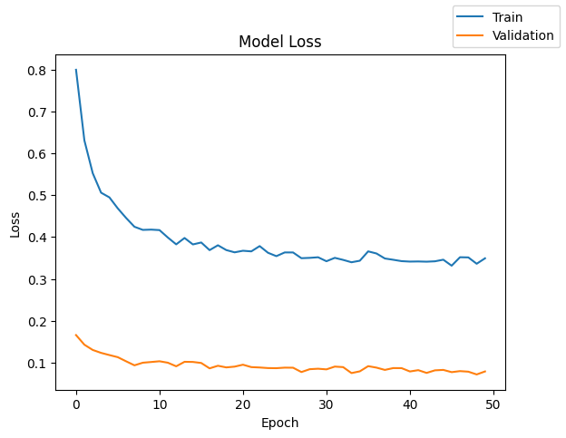

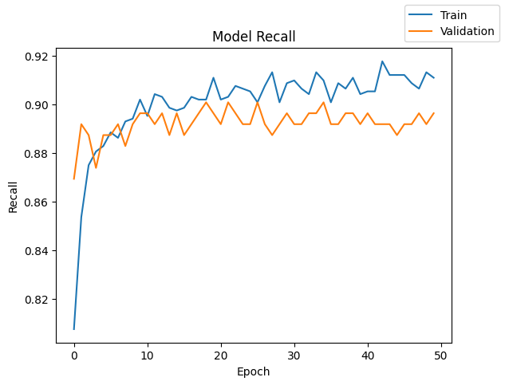

```python
# Plot learning curves
plot(history, 'loss')
plot(history, 'recall')
```